# Ant species but not trait diversity increases at the edges: insights from a micro‐scale gradient in a semi‐natural Mediterranean ecosystem - Frasconi Wendt - - Ecological Entomology - Wiley Online Lib

[Ecological Entomology](https://onlinelibrary.wiley.com/journal/13652311)

[Early View](https://onlinelibrary.wiley.com/toc/13652311/0/0)

[figure not shown]

Original Article

Full Access

# Ant species but not trait diversity increases at the edges: insights from a micro‐scale gradient in a semi‐natural Mediterranean ecosystem

[Clara Frasconi Wendt](https://onlinelibrary.wiley.com/action/doSearch?ContribAuthorStored=Frasconi+Wendt%2C+Clara)

[Filippo Frizzi](https://onlinelibrary.wiley.com/action/doSearch?ContribAuthorStored=Frizzi%2C+Filippo)

[Giulia Aiello](https://onlinelibrary.wiley.com/action/doSearch?ContribAuthorStored=Aiello%2C+Giulia)

[Paride Balzani](https://onlinelibrary.wiley.com/action/doSearch?ContribAuthorStored=Balzani%2C+Paride)

[Giacomo Santini](https://onlinelibrary.wiley.com/action/doSearch?ContribAuthorStored=Santini%2C+Giacomo)

First published: 14 February 2021

https://doi.org/10.1111/een.13020

Associate Editor: Inge Armbrecht

## Abstract

1. Different habitat types are generally associated with shifts in ant species and traits, and even along a micro‐scale woodland–grassland gradient, ant biodiversity may change at the edge proximities as a result of abiotic alterations. However, to the best of authors' knowledge, the changes in ant diversity along this type of gradient are understudied, especially from a functional perspective.

2. The authors sampled ant species in eight micro‐scale woodland–grassland gradients in a Mediterranean ecosystem, each comprising 16 m, to assess how ant species diversity, community composition, functional structure, and single‐ and multi‐trait functional diversity change at the edge and in the two adjacent habitats (woodland and grassland) as the distance from the edge increases.

3. No differences in species richness, species diversity, and community composition were found within the woodland and grassland habitats. Distance from the edge into the adjacent habitats explained changes in functional structure and diversity, which mainly increased in the grassland habitat; body length, leg length, sugar‐based diet, dominant behaviour, and multi‐trait diversity increased in the grassland. Along the micro‐scale gradient, edges showed the highest species diversity and community composition that resulted from the overlap of the communities from the adjacent habitats.

4. This study shed light on changes in ant species and traits along a micro‐scale woodland–grassland gradient, and it highlights the importance of integrating different diversity approaches (functional and taxonomic) at a micro‐spatial scale.

## Introduction

Edges are defined as transition zones between two different habitat types and are important spatial attributes that influence local biodiversity (Murcia, 1995). The edge, together with other landscape characteristics such as fragmentation and mosaic size, is an essential predictor of insect diversity and community assemblage (Kormann *et al*., 2015; Dominik *et al*., 2018). Alterations in microclimatic conditions, vegetation structure, and plant composition at the edge may alter the composition of other trophic levels, for example, insects (Batáry *et al*., 2012; Magura, 2017). The effects on biodiversity mediated by edges have been studied for several years, especially in tropical woodlands and agroecosystems and in light of conservational and agricultural implications (Fahrig, 2003). For example, in agricultural landscapes, field edges rather than the adjacent agricultural field seem to promote beetle diversity (Boetzl *et al*., 2019).

Along a grassland–woodland gradient, the outcomes of the effects mediated by edges on biodiversity may be positive, neutral or negative, depending on the context, and taxon analysed (Fahrig *et al*., 2019). Edges may offer refugia to certain species from the close open grasslands (Hevia *et al*., 2013; Martello *et al*., 2016; Gallé *et al*., 2018) and when they border with a forest they may even be characterised by higher insect diversity compared to the woodland fragments (González *et al*., 2018). Edge communities may have a composition intermediate between that of the adjacent grassland and woodland habitats and may represent a more gradual transition from a more heterogeneous, for example, pristine woodland, to a more homogeneous habitat type, for example, an agricultural field (Martello *et al*., 2016). However, the abrupt change in vegetation structure and microclimatic conditions such as light and wind at the edge (Laurence *et al*., 2007) may negatively impact insect community composition and cause a decrease in insect abundance. The result is a shift in functional traits, such as body size in carabid beetles, and functional groups from the woodland interior to the grassland centre, with closed‐habitat specialists being lost over open‐habitat generalists (Martello *et al*., 2016).

The role of the edge and its effects on biodiversity garner interest in different contexts, for example, when it associates woodland–grassland, urban–rural, and forest–farmland ecotones, and when different spatial scales are incorporated (Ting & Shaolin, 2008). Changes in species composition and species richness may occur at small distances too (Stone *et al*., 2018), for example, resulting in a decrease in beetle species richness and community composition in the forest habitat within less than 10 m from the edge, and at larger distances from edges. González *et al*. (2015) showed that edge effects may influence arthropod functional groups up to 20 m into woodlands. Thus, changes along a gradient characterised by a transition from a habitat type to the next one, delimited by an edge, implies different vegetation structure, microclimatic conditions, and resources availability, which eventually may act as filters on ground‐dwelling arthropods (e.g. Siemann, 1998; Lassau & Hochuli, 2004; Nooten *et al*., 2019). Semi‐natural mosaic landscapes, characterised by small grassland patches embedded within woodlands, support high biodiversity and essential ecosystem functions and processes (Tscharntke *et al*., 2005) and may offer an interesting context to study the role of environmental filtering along with different habitats on functional structure and diversity at the micro‐scale level and at edges or in close proximity to edges.

Among insects, ants have been widely used as ecological indicators based on their species identity and their functional traits, given their sensitivity towards environmental changes and disturbance (Ellison, 2012). Ants are diverse, abundant, and easy to sample, and their ecology is well‐known compared to other insect groups (Lach *et al*., 2010). Ants have also been recognised as important ecosystem engineers for their ability to modify their surroundings through abiotic changes and biotic interactions (Folgarait, 1998). The relationship between different habitat types and ant diversity and community composition has been assessed in many studies (Sobrinho & Schoereder, 2007; Brandão *et al*., 2011); however, as for other insect groups, their responses in relation to edges are not universal and vary greatly depending on the analysed ecosystem and the spatial scale (Kotze & Samways, 2001; González *et al*., 2015). For example, in a xeric alluvial ecosystem, ant species richness increased at the field edges relative to the woodland or open field (Steiner & Schlick‐Steiner, 2004), while between different agricultural fields, edges did not seem to have a specialised ant community composition (Dauber & Wolters, 2004).

Along a spatial gradient, for example, woodland‐grassland, the environment may act as a filter on ant species and drives changes in ant functional composition (e.g. Wiescher *et al*., 2012; Nooten *et al*., 2019) at large‐scale (Arnan *et al*., 2014) and at small‐scale (Gibb & Parr, 2013). The association between environment and ant body size is described in the “size‐grain” hypothesis (Kaspari & Weiser, 1999): large and small body‐sized ants have a different perception of their environment. While ants with large body size and long legs perceive it as more planar, species with small body sizes and short legs perceive it as more rugose. Finally, body size and leg length influence ant foraging ability and speed (Gibb & Parr, 2010). Thus, considering that woodland and grassland habitats differ in environmental characteristics (e.g. plant species, vegetation height), it is expected that woodland‐grassland gradients would harbor different ant functional traits.

In this study, we aimed to evaluate how ant species, trait diversity, and community composition vary as the distance from an edge increases, namely along a woodland–grassland gradient stretching from an edge into the two adjacent habitats (woodland and grassland). We selected a micro‐scale gradient along with different contiguous habitats in a semi‐natural Mediterranean ecosystem where the woodland was separated from the grassland by a narrow edge. Ant biodiversity was assessed at a distance of 0, 4, and 8 m from edges into the adjacent woodland and grassland. We addressed the following questions: (i) How do ant species richness, diversity, and functional traits change along a micro‐scale woodland–grassland gradient? and (ii) Does the ant community composition vary along the micro‐scale gradient? Given the differences in vegetation structure and microclimatic conditions between the habitats, we expected a difference in ant species richness and species diversity and a gradual shift in community composition between habitat types. Regarding functional composition, we expected functional structure and diversity to change in response to the habitat type, thus according to the environmental changes that occur in each habitat (e.g. Yates *et al*., 2014; Nooten *et al*., 2019). For example, following the size–grain hypothesis (Kaspari & Weiser, 1999), we predicted that mean body size and leg length would increase in the more planar environment (i.e. grassland habitats). Following the “habitat heterogeneity hypothesis” (MacArthur & Wilson, 1967), we expect the more diverse environment (i.e. woodland habitats), in terms of resources and diversity in microclimatic conditions, to support a higher ant trait diversity. We expected the edges to share similar species and functional structure and diversity with both adjacent habitats, meaning a higher species and trait diversity at the edge compared to the woodland and grassland habitats. We expected that as the distance from the edge increased, community composition, species diversity, and functional structure and diversity would increasingly differ from those at the edge.

## Materials and Methods

### *Study site*

The study was conducted approximately 30 km from Florence (Tuscany, Italy, 43°56′22″N, 11°11′20″E). The study site is located within the Mediterranean region at an elevation of approx. 500 m a.s.l., and is characterised by mild, rainy winters, and hot, dry summers (Lionello *et al*., 2006). The region has a mean temperature of 14°C and mean precipitation of 860 mm/year.

Within this context, we selected eight micro‐scale sampling sites comprising a woodland and a grassland habitat (Fig. 1). The tree strata of the woodland habitat were characterised by different oak species, i.e. *Quercus cerris* and *Quercus pubescens*, with sparse pine (*Pinus* sp.) and cypress trees (*Cupressus sempervirens*). The shrub strata, which was almost the same height as the tree strata, was defined by brooms, strawberry trees (*Arbutus unedo*), blackthorn (*Prunus spinosa*), and *Cistus* sp., while a layer of leaf litter characterised the lower stratum. The grassland habitat was characterised by *Dipsacus* sp., *Hypericum perforatum*, and *Trifolium* sp., as well as small open spaces and other annual herbs and graminoids and some shrubs, such as *Prunus spinosa* and *Lavandula* sp., at low heights. Grasslands showed some differences in area, ranging between 390 and 3530 m<sup>2</sup>. Additionally, anthropogenic activities in these grasslands, such as low‐intensity mowing and tillage, have occurred from 1950 ([http://www.regione.toscana.it/‐/geoscopio](http://www.regione.toscana.it/-/geoscopio)) until 2015, with some grasslands showing signs of low‐intensity tillage until spring 2018 and thus low biomass accumulation. Edges separating the woodland from the grassland habitat were not characterised by specific plant species or vegetation type and accounted for plant species belonging to both adjacent habitats. Indeed, edges were quite sharp, so the gradient into the adjacent habitats resulted in a sudden change in vegetation structure.

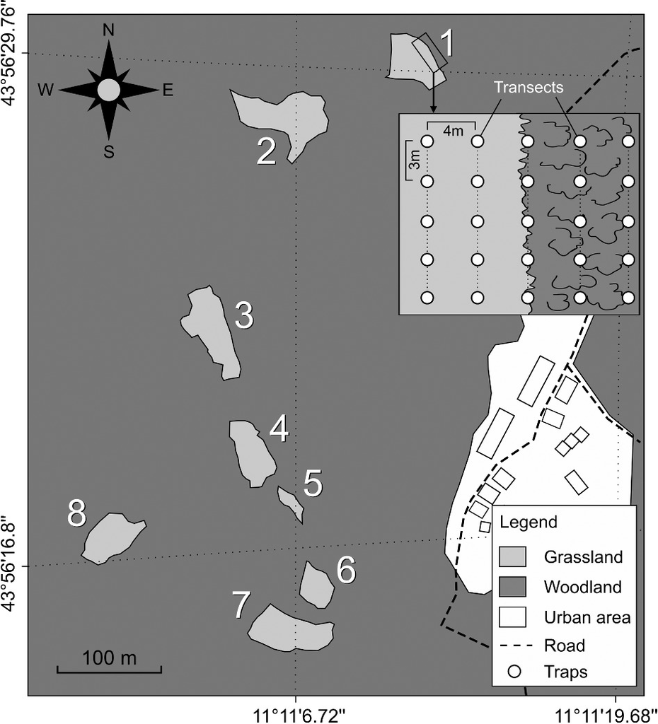

**Fig. 1**

Map of the eight sampling sites (Firenze, Italy) showing grasslands (light grey) embedded into woodlands (dark grey). A scheme shows the position of the five transects and the pitfall traps (in circles) along the micro‐scale gradient.

### *Ant sampling and ant functional traits*

At each sampling site, we established five 12 m transects at a distance of 4 m apart and parallel to the edge. At each sampling site, we had a micro‐scale gradient characterised by two woodland transects (one at 8 m and one at 4 m from edge), an edge transect (0 m from edge), and two grassland transects (at 4 and 8 m from edge). These different distances from the edge into the adjacent habitats defined our micro‐scale woodland–grassland gradient.

In June 2019 (summer), we collected ants in all eight sampling sites. Along each transect, we placed five pitfall traps spaced 3 m apart consisting of a 50 ml Falcon® tube (diameter ca. 30 mm) with an 80% diluted ethanol and 2% glycerol solution for a total of 25 traps per sampling site. Traps were buried in the ground with the rim of the trap flush with the level of the soil surface. Traps were checked every 2 days, and refilled with the alcohol solution when necessary. After 7 consecutive days, the traps were collected and brought to the laboratory, and ants were identified to the species level (Czechowski *et al*., 2012; Lebas *et al*., 2016). Ant species were confirmed by a specialist.

To determine ant community functional structure and diversity, we measured three functional traits (Weber's length, head length, and leg length), one categorical trait (diet preferences), two binary traits (behaviour and activity), and one ordinal trait (polymorphism). Traits were chosen according to their ecological importance and implications (Table S1) and retrieved from available literature (Arnan *et al*., 2014; Parr *et al*., 2017; Frasconi Wendt *et al*., 2020). Continuous functional traits were measured on 15 individuals per monomorphic species and 10 individuals per worker caste for polymorphic species (e.g. *Messor ibericus*). Some species had a low number of individuals so only the available individuals were measured. The average of each trait per species was used for further analysis.

### *Data analyses*

We considered ant incidence data, which corresponded to the number of pitfall traps in each transect that contained a given species. We used incidence data over raw ant abundance data because ant abundance has been shown to be biased by the proximity of the pitfall traps to an ant nest entrance and may be more suited to estimate ant biomass rather than biodiversity (Gotelli *et al*., 2011).

We estimated species diversity along the gradient based on Hill's numbers (Chao *et al*., 2014), which estimate sampling unit‐based species richness (*q* = 0), Shannon's diversity index (*q* = 1) and Simpson's diversity index (*q* = 2) with 95% CIs.

We used two community functional metrics, namely functional structure, which is based on community‐weighted‐mean (CWM), and single‐ and multi‐trait functional diversity (Rao's quadratic entropy, RaoQ). The CWM is based on the most dominant trait and is defined as the mean trait value for each species weighted by the abundance of the species (in our case, incidence) carrying that trait (Garnier *et al*., 2007). The CWMs were calculated for each trait separately and at each of the five distances along the micro‐scale gradient. Functional diversity measured trait dissimilarity, or the degree of trait variation within a community (Botta‐Dukat, 2005; Mason *et al*., 2005). Within the functional diversity indices, RaoQ takes into account species abundance and is largely used to determine functional diversity (Botta‐Dukat, 2005). As for the CWM, we used species incidence rather than species abundance to measure trait diversity.

To check for differences in ant functional structure and functional diversity as the distance from the edge increased, we conducted generalised linear mixed models (GLMM) with the CWMs, single‐ and multi‐trait RaoQ as response variables, distance from the edge (woodland–grassland gradient) as an explanatory variable, and sampling site as a random effect. For each response variable, we ranked the null, linear and quadratic model using the Akaike Information Criterion (AIC). The model having the lower AIC by at least two points was selected (Burnham & Anderson, 2002). When the AIC values were similar (ΔAIC <2), the more parsimonious model (i.e. the linear one) was favoured.

Distance‐based redundancy analysis (dbRDA) with Bray–Curtis distance was used to evaluate changes in ant community composition along the micro‐scale gradient, followed by an anova performed in blocks (i.e. the eight sampling sites) and based on 999 permutations. Then, we overlaid ant CWMs and RaoQ onto the ordination and correlated them to the ordination.

All statistical analyses were performed using cran software R 3.6.1 (R Core Team, 2019) with ‘iNEXT,’ ‘vegan,’ ‘FD,’ ‘AICcmodavg,’ and ‘lme4’ packages (Laliberté & Legendre, 2010; Bates *et al*., 2015; Oksanen *et al*., 2017; Mazerolle, 2019).

## Results

We collected a total of 29 ant species belonging to four subfamilies: Dolichoderinae, Formicinae, Myrmicinae, and Ponerinae. The subfamilies of Myrmicinae and Formicinae accounted for 13 species each, while Dolichoderinae and Ponerinae included two and one species, respectively. *Myrmecina graminicola* was the most common species, followed by *Lasius psammophilus*, *Temnothorax parvulus*, and *Solenopsis fugax*. Some species, such as *Camponotus fallax*, *Colobopsis truncate*, and *Lasius fuliginosus*, only occurred in one site (Table S2).

Species richness was similar across all sampling habitats (Fig. 2), also shown by the large overlap of their 95% CIs. Shannon and Simpson diversity indices were highest at the edge, with the 95% CI being clearly separated from the woodland and grassland (Fig. 2). In terms of Shannon and Simpson diversity indices, the edge was followed by the grassland (at both 4 and 8 m from edges), which showed a wide overlap in the CIs. Lower values of Shannon and Simpson diversity indices were recorded at 4 m from the edge in the woodland, although there was a wide overlap within the woodland habitat (Fig. 2).

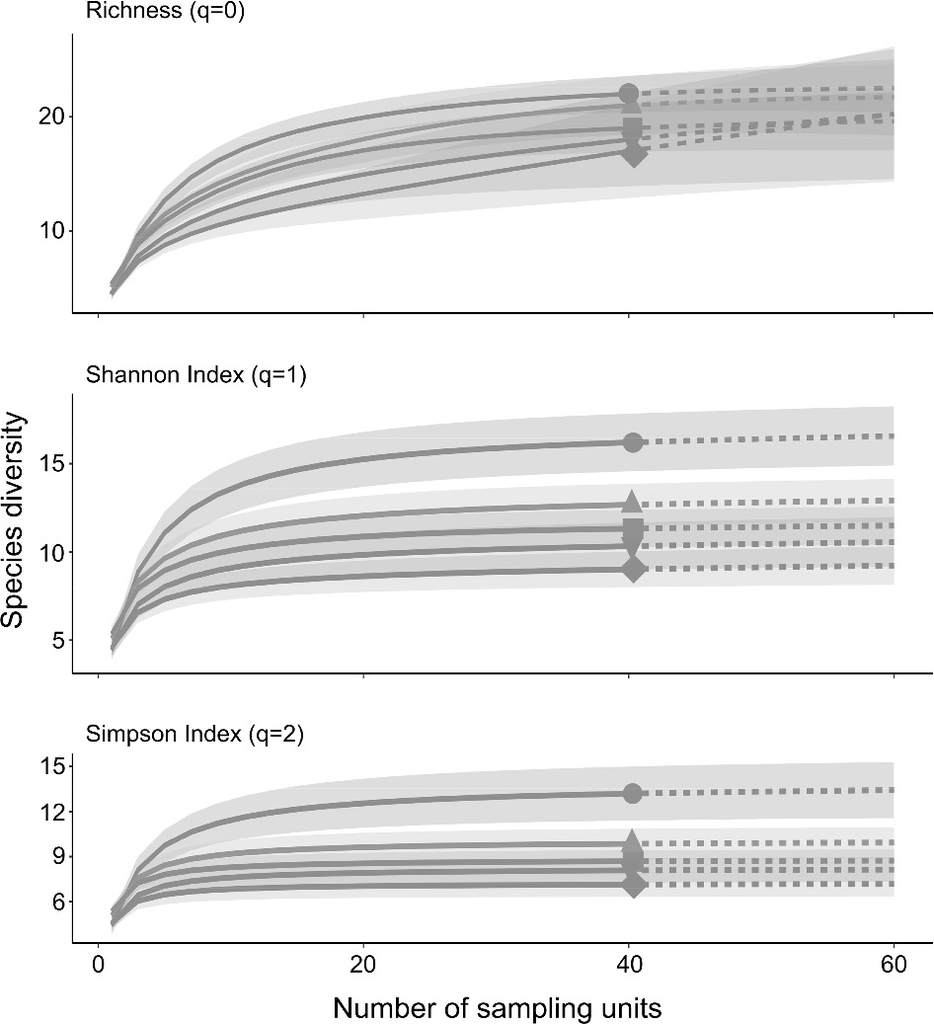

**Fig. 2**

Sample‐size‐based estimates of ant (a) Species richness (*q* = 0), (b) Shannon Diversity Index (*q* = 1) and (c) Simpson Diversity Index (*q* = 2), with the associated 95% CI. Continuous lines refer to actual sample numbers, while dashed lines to extrapolated samples. Colors and different symbols refer to different sampling habitats: red circle = edge; dark green triangle = 4 m distance from the edge into grassland habitat; green square = 8 m distance from the edge into grassland habitat; blue rhombus = 4 m distance from the edge into woodland habitat; magenta triangle = 8 m distance from the edge into woodland habitat. [Colour figure can be viewed at [wileyonlinelibrary.com](http://wileyonlinelibrary.com/)].

In general, the mean value (±SD) of Weber's length was 1.35 ± 0.62 mm, head length measured 0.91 ± 0.32 mm, and the relative leg length was 2.22 ± 0.70 mm. Looking at the dietary preferences, the community was dominated by ant species with a generalist diet (55%), followed by sugar‐based diets (30%), scavengers (12%), and a seed‐based diet (3%). Most species (64%) were classified as ‘subordinate’ and as ‘a not strictly diurnal and nocturnal activity type’ (80%).

Results of the GLMM showed that distance from the edge explained changes in ant functional structure (CWM) and single‐ and multi‐trait functional diversity (RaoQ; Tables 1 and S3). A total of 7 out of 12 CWM values responded to the micro‐scale woodland–grassland gradient (Fig. 3; Table 1), with most of the CWM values increasing in the grassland. The functional structure of two continuous traits (Weber's length and relative leg length), the sugar‐based diet and the dominant behaviour increased from woodland to grassland. The generalist and scavenger diets and the subordinate behaviour increased in the woodland. Three out of seven RaoQs were explained by distance to edge, with the functional diversity of the two continuous traits and the behaviour increasing from the woodland to the grassland (Fig. S1, Table S3). Multi‐trait functional diversity increased in the grassland as the distance from the edge increased (Fig. 3, Table 1).

Table 1. Results of the generalised linear mixed models associating response variables, namely ant functional structure (CWM) and on multi‐trait functional diversity (RaoQ), to micro‐scale woodland‐grassland gradient (increasing distance from edge) as an explanatory variable.

| Response variable | Trait | Categories | ΔAIC | Model type |
| --- | --- | --- | --- | --- |
| Functional structure |  |  |  |  |
|  | WL |  | 1.22 | L |
|  | HL |  | 6.12 | N |
|  | RLL |  | 2.30 | Q |
|  | Diet | Generalist | 3.68 | Q |
|  |  | Scavenger | 1.97 | L |
|  |  | Sugar‐based | 1.84 | L |
|  | Behaviour | Subordinate | 2.11 | Q |
|  |  | Dominant | 2.85 | Q |
| Functional diversity |  |  |  |  |
|  | Multi‐trait RaoQ |  | −2.14 | L |

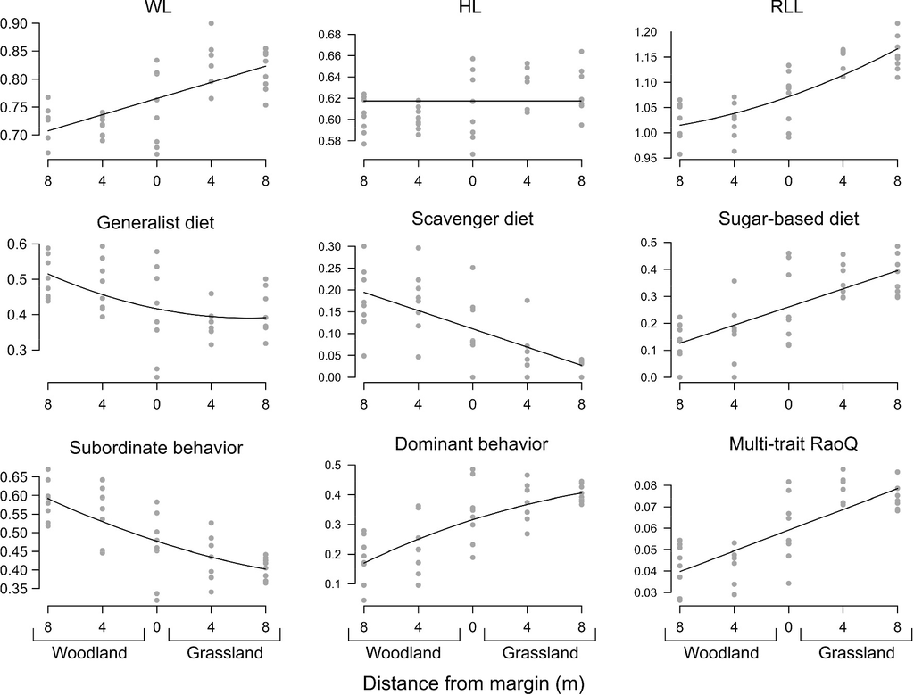

**Fig. 3**

Plots of the model predictions for the response variables (*y*‐axis) responding to the micro‐scale woodland‐grassland gradient (*x*‐axis). Distance from the margin is indicated as 8, 4, and 0 m into the adjacent habitats. HL, head length, RLL, relative leg length; WL, Weber's length.

The dbRDA showed a large overlap in community composition within the woodland and within the grassland habitat and sites of the edges were closer to sites of the woodland habitat (Fig. 4; see RDA with single‐trait RaoQ in Fig. S2). The CWM and the multi‐trait RaoQ vectors which significantly correlated with the ordination (Table S4) were plotted (Fig. 4). The CWMs of scavenger and generalist diet, and subordinate behaviour were associated with the woodland, while the CWMs of all continuous traits, sugar‐ and seed‐based diet, dominant behaviour and polymorphism, and the multi‐trait RaoQ were associated with the grassland. Results of the dbRDA revealed that ant community composition responded to increasing distance from the edge along the micro‐scale woodland–grassland gradient (anova; *F*<sub>1.37</sub> = 51.42, *P* < 0.001).

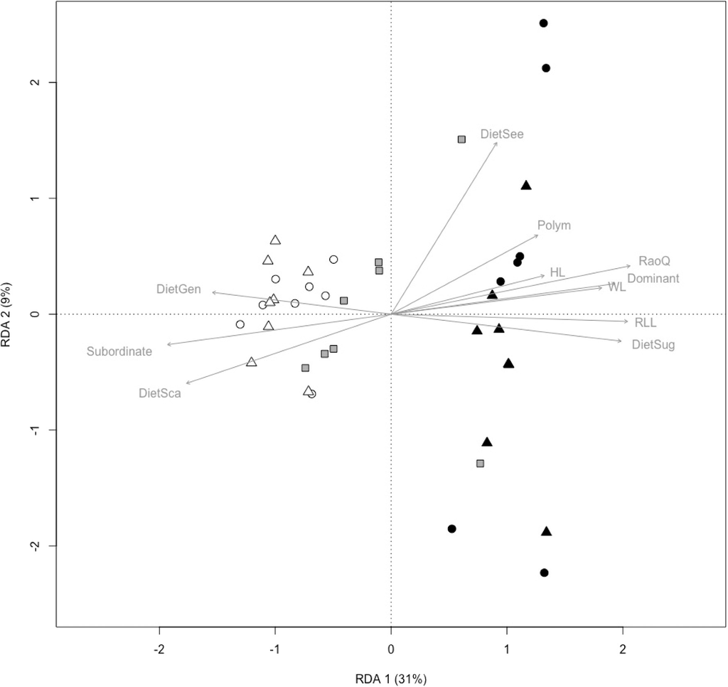

**Fig. 4**

Distance‐based redundancy analysis of ant community composition with vectors of ant community‐weighted‐means and multi‐trait Rao's quadratic entropy (RaoQ). White circles represent woodland habitat at 4 m distance from the edge, white triangles woodland habitat at 8 m distance from the edge, grey quadrats the edge, black circles correspond to grassland habitat at 4 m distance from the edge, and black triangles grassland habitat at 8 m distance from the edge. Only vectors with a significant correlation with the ordination are plotted: DietGen, generalist diet; DietSca, scavenger diet; DietSee, seed‐based diet; DietSug, sugar‐based diet; Dominant, dominant behaviour; HL, head length; Polym, worker's polymorphism; RaoQ, multi‐trait RaoQ; RLL, relative leg length; Subordinate, subordinate behaviour; WL, Weber's length.

## Discussion

Our results provide evidence for differences in ant species diversity, functional traits, and community composition along a micro‐scale woodland–grassland gradient in a semi‐natural Mediterranean habitat. Overall, we found that within the same habitat type ant community composition showed a large overlap. However, grassland habitats had different ant composition and higher functional diversity than woodlands, while edges had higher ant species diversity.

Regarding ant species richness, it did not change between habitats, with grasslands, edges, and woodlands sharing a similar number of species. At a small scale, Dröse *et al*. (2019) reported similar results, finding no differences in ant species richness and diversity between the forest and grassland habitats. We found higher species diversity based on Shannon and Simpson diversity indices in the edges, which may suggest that edges offer a higher number of environmental niches for ants to exploit. These findings on ant species richness and diversity contrast with previous studies on ant abundance and diversity, which report an increase in ant species richness and diversity in open and generally warmer environments such as semi‐natural grasslands, as ants are thermophilic (Kotze & Samways, 2001; Lassau & Hochuli, 2004).

Results on community composition agreed with our predictions and with past studies along small‐scale gradients (e.g. Dröse *et al*., 2019), showing a difference in ant community assemblage between habitats. Compared to the adjacent habitats, edges did not show a specific edge‐associated community composition, which has been reported for other key insect groups, for example, carabid beetles (Magura, 2017). At the edges, community composition from woodland and grassland habitats overlapped, suggesting that edges do not seem to limit the establishment and/or occurrence of grassland specialists nor of woodland specialists, and edges may instead offer refugia to different species. However, further analysis at the species level is needed to assess it.

As for ant functional structure and diversity, we found that both indices changed along the micro‐scale gradient, and distance from the edge into the two adjacent habitats explained most of their changes. Changes in the functional structure and diversity of continuous functional traits in response to environmental filtering have been reported for many ecological indicator species (Lassau & Hochuli, 2004; González *et al*., 2015; Boetzl *et al*., 2019; Nooten *et al*., 2019). Along our micro‐scale gradient, differences in the continuous functional traits may reflect shifts in habitat type, for example, an increase in the average body length and leg length from the woodland to the grassland. In particular, the positive relationship between body size and leg length and their increase from a more closed to a more open ecosystem has been observed on different continents too (Kaspari & Weiser, 1999; Lassau & Hochuli, 2004; Gibb & Parr, 2013; Nooten *et al*., 2019). Ants with large body size and long legs are associated with simpler and more open habitats, while as environmental rugosity (number of interstices) increases, ant body size decreases (Kaspari & Weiser, 1999; Gibb & Parr, 2013). In a manipulative experiment, Farji‐Brener *et al*. (2004) found that as leaf litter density increased, body size and leg length decreased, and ants with small body size were faster at discovering food resources. This may imply that along our micro‐scale gradient, the different environmental conditions at each habitat act as filters on ant functional structure and diversity. For example, grasslands, characterised by small open spaces, herbs, small shrubs, and less leaf litter accumulation, may represent a more planar environment to ants and may have favoured an increase in ants with large body size and long legs. However, as we do not have environmental variables describing the two habitats, for example, plant height and biomass accumulation, these changes in body size along the micro‐scale gradient may occur because of other factors, such as differences in climatic conditions between habitats. Compared to the shaded woodland, the warmer grassland habitat may be characterised by a more heat‐tolerant ant community with specific traits allowing species to live under hotter environmental conditions (Arnan *et al*., 2015). For example, large body‐sized ants typically show a lower desiccation rate (Bujan *et al*., 2016) and may thus be advantaged in more open and hotter habitats, such as the grassland one.

Apart from continuous traits, the percentage of ant diets changed along the gradient; ant species with generalist and scavenger diets decreased, while ant species with a sugar‐based diet increased in the grassland. We suggest that changes in the percentage of generalist or more specialised diets may result from the different productivity in each habitat, with ants with a specialised diet, such as the sugar‐based diet, increasing in grasslands where liquid foods may be more available (Arnan *et al*., 2014). Besides being linked to ant diets, different habitat types may influence the ability to monopolise resources: ants have a higher chance to find and monopolise food in more open and less complex habitats (Parr & Gibb, 2012). With regards to ant behaviour, the proportion of ants with a dominant behaviour increased in the grassland, while the proportion of subordinate ants was higher in the woodland habitats. Dominant ant species show fast recruitment, a high aggressiveness, and the ability to monopolise food resources and compared to the subordinate species often show a lower thermal tolerance (Cerdá *et al*., 1998; Arnan *et al*., 2018). Furthermore, ant behaviour has been linked to environmental characteristics too (e.g. Gibb, 2005; Santini *et al*., 2011; Radnan *et al*., 2018): Andersen (1995) found that a more open (less complex) and warm habitat promotes dominant ants. Thus, along the woodland‐grassland gradient, a more open habitat, such as the grasslands, may have favoured an increase in dominant species.

The functional diversity analysis led to similar conclusions, namely an increase in ant single‐ and multi‐trait functional diversity from the woodland to the grassland, suggesting that differences in habitat type may have caused changes in ant functional diversity too. The higher multi‐trait diversity in the grassland suggests that a wider range of functional strategies is found in this habitat, which in turn may imply a higher number of functional strategies and ecological functions (Azcárate *et al*., 2013). Thus, even at the small‐scale, grasslands may provide a higher diversity in microhabitats, which in turn may promote ant communities characterised by a higher diversity in body sizes, leg length, and co‐occurrence of dominant and subordinate species, whereas ant communities with a lower functional diversity seemed to characterise the woodland habitats (Arnan *et al*., 2012). Following the “habitat heterogeneity hypothesis” (MacArthur & Wilson, 1967), our results suggest woodlands to be a less heterogeneous and slightly colder habitat as they supported functionally more homogeneous communities (low values for RaoQ).

Taking these results together, we found that edges are characterised by higher species diversity, but not by a higher functional structure and functional diversity. These results suggest that edges do not seem to support a specific‐edge associated myrmecofauna and may instead represent the overlap zone between the assemblages of the two adjacent habitats (Martello *et al*., 2016). The inclusion of both grassland and woodland species at the edges, and thus an increase in species diversity, as reported in other studies (e.g. Salas‐Lopez *et al*., 2017), may suggest the similarity of the edges to both habitats, for example, in terms of vegetation structure and resource and nest site availability. Edges, although narrow in width, shared a vegetation structure similar to the adjacent habitats and supported ants from both contiguous habitats.

Last, we would like to mention that grasslands showed different histories of land use, although differences in years since land abandonment were quite small (less than 4 years). Land abandonment or intensification of anthropogenic practices may re‐shape patch attributes, such as edges, as well as their biodiversity, and may result in an insect diversity decline or an increase in ant functional and species diversity (Azcárate & Peco, 2012). Nevertheless, years since land abandonment were not considered in this study because all grasslands showed signs of low‐intensity anthropogenic activities within the last 1–4 years from sampling. Furthermore, we did not include years of land abandonment given that this timeframe is shorter than the general span of short‐term abandonment (5–15 years) considered in previous studies (Kormann *et al*., 2015). However, we cannot exclude that the results for the grasslands may have been influenced by years of land abandonment. Thus, further investigation needs to be done to consider this aspect.

In conclusion, in a mosaic landscape, namely woodlands interrupted by small grasslands, we found no changes in species richness, but species identity and traits changed between woodlands and grasslands, while community assemblage was the same at 4 and 8 m from the edge within the same habitat. Our findings shed light on the role of edges and the shift in functional trait structure, diversity, and community composition between different habitats. Furthermore, our results value the importance of assessing micro‐scale changes in biodiversity in this mosaic landscape and represent a starting point to be compared with future studies evaluating the effects of micro‐scale woodland–grassland gradients on ant functional structure and diversity.

## Acknowledgements

We would like to thank Elisa Carta, Maria Innocenti, and Daniela Muzzicato for their help during fieldwork and sorting and Fabrizio Rigato for help in identifying ant species. The authors declare that there were no conflicts of interest in conducting the study.

## Author contributions

**Clara Frasconi Wendt**: conceptualisation, field work, data analysis, and writing – original draft. **Filippo Frizzi**: conceptualisation, field work, data analysis, and writing – review and editing. **Giulia Aiello**: field work and writing – review and editing. **Paride Balzani**: conceptualisation, field work, data analysis, and writing – review and editing. **Giacomo Santini**: conceptualisation, field work, data analysis, and writing – review and editing.

## Data availability statement

The data that support the findings of this study are available from the corresponding author upon reasonable request.

## References

[figure not shown]

Online Version of Record before inclusion in an issue

### Details

- © 2021 The Royal Entomological Society

### Keywords

  - [ant diversity](https://onlinelibrary.wiley.com/action/doSearch?field1=Keyword&text1=ant%20diversity)
  - [community composition](https://onlinelibrary.wiley.com/action/doSearch?field1=Keyword&text1=community%20composition)
  - [functional traits](https://onlinelibrary.wiley.com/action/doSearch?field1=Keyword&text1=functional%20traits)
  - [woodland‐grassland gradient](https://onlinelibrary.wiley.com/action/doSearch?field1=Keyword&text1=woodland%E2%80%90grassland%20gradient)

### Publication History

  - Version of Record online: 14 February 2021
  - Manuscript accepted: 26 January 2021
  - Manuscript revised: 25 January 2021
  - Manuscript received: 31 January 2020